# Tarea 2: Predicción de promotores.

Lucía Graña

01/03/2016

### Introducción

La mayoría de los programas que predicen promotores se basan en homología o propiedades de las secuencias, como el uso de codones. Kanhere y Bansal, 2005, proponen un algoritmo basado en diferentes propiedades de las secuencias como estabilidad, plegabilidad y curvatura. Las regiones *upstream* son menos estables, más rígidas y curvadas que las regiones *downstream*, en esto se basa el algoritmo de predicción de promotores propuesto por Kanhere y Bansal, 2005, en las diferencias de estabilidad entre regiones promotoras y no promotoras.

### Objetivos:

1. Completar el codigo fuente del programa 1.1 para implementar el predictor de Kanhere y Bansal.
2. Diseñar una figura donde se muestra gráficamente D, E1 y E2 para una posición n.
3. Predecir promotores en todas las secuencias del fichero K12_400_50_sites.
4. Graficar con que frecuencia se predicen promotores en el intervalo -400,50.

### Resultados:

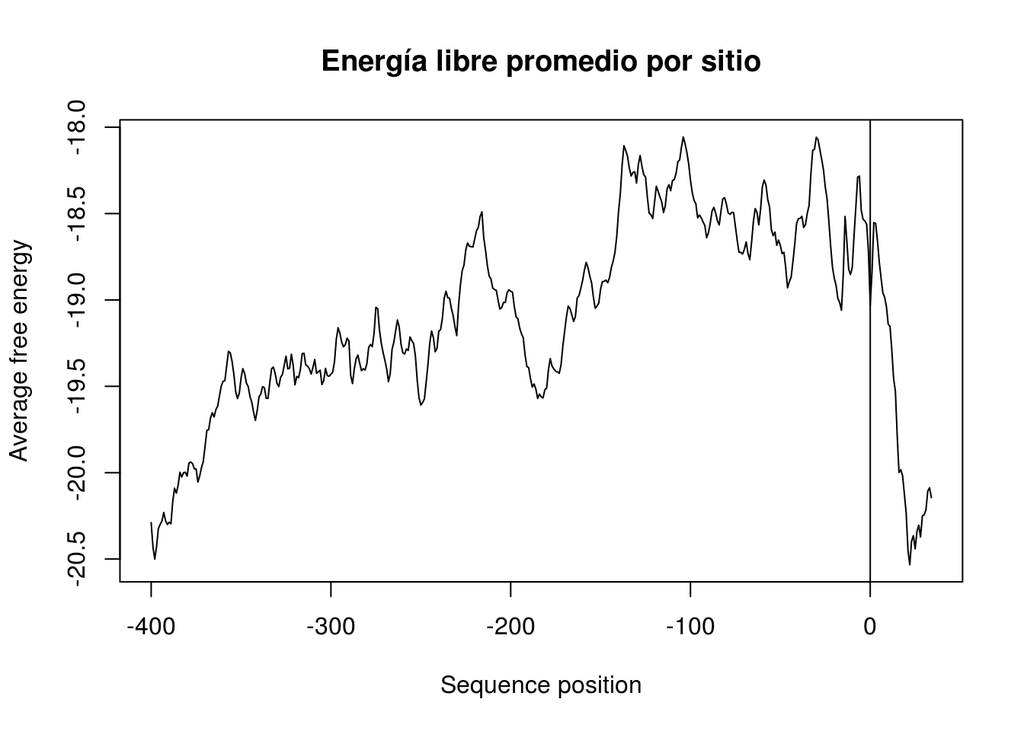

2. El siguiente gráfico permite visualizar los valores de D(n), E1(n) y E2(n), para cada sitio en una de las secuencias.

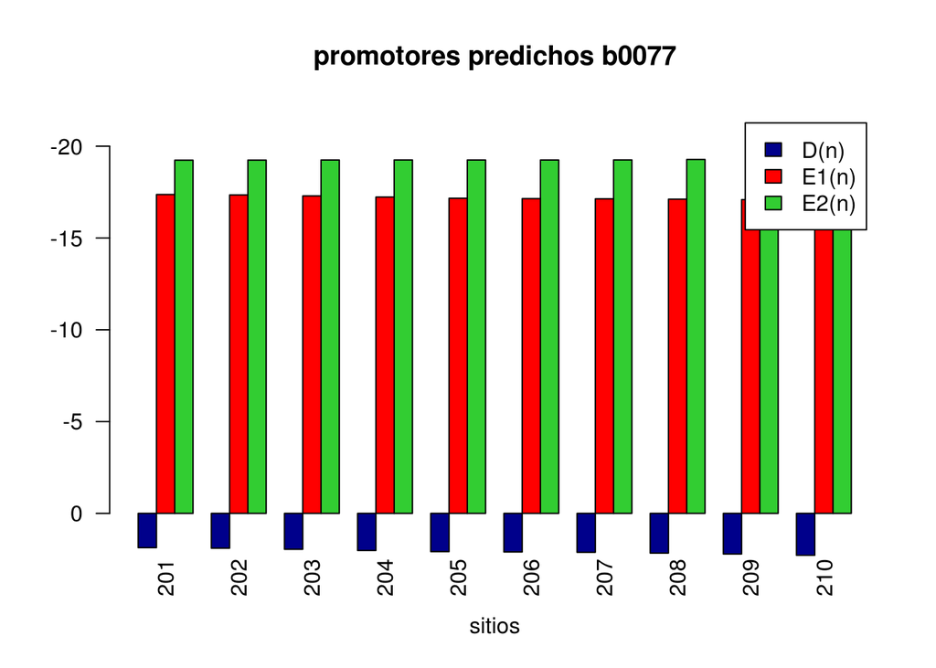

4. Se estimó la frecuencia con que se predicen promotores en cada sitio dentro de las secuencia. La predicción de promotores se concentra en una región entre -160 y -200 pb. Esta frecuencia se estimó como:

número de veces que un promotor se predice en ese sitio / número total de sitios

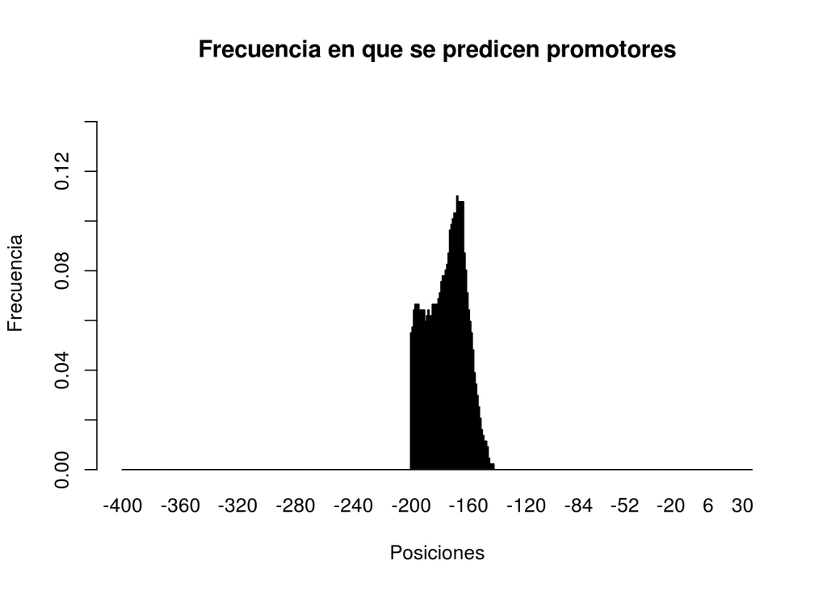

Tomando en cuenta los falsos positivos:

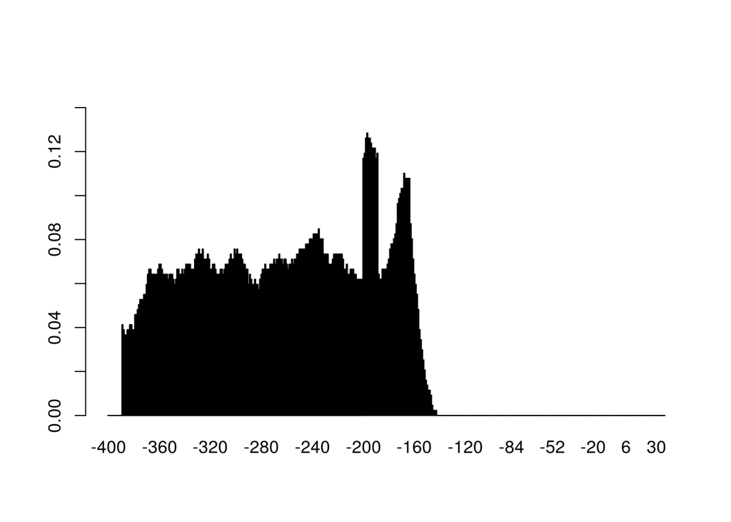

### Valores de cutoff

La elección de los valores de cut-off para D(n) y E1(n), es una tarea difícil, de acuerdo a los resultados presentados en Kanhere y Bansal 2005, la elección de estos valores genera un compromiso ente precisión y sensibilidad. En el caso de este trabajo, si se utilizan valores de cut-off D(n) = 0.20 y E1(n) = -20.99, se pueden predecir promotores en un mayor número de secuencias, o sea, a medida que se restringen estos números, se pierde la capacidad de predecir promotores en más secuencias. El problema es que en este caso (D(n) = 0.20 y E1(n) = -20.99) la precisión es muy baja, 0.21. Entonces, hay que llevar los cut-off, a valores que se haya demostrado, generan predicciones de alta sensibilidad y precisión. De acuerdo con Kanhere y Bansal 2005, para aumentar la precisión hay que usar valores de D(n) más altos, y valores de E1(n) menos negativos. A continuación se muestran los resultados de esta modificación.

### Resultados obtenidos con D(n) = 2.45 y E1(n) = -17.99

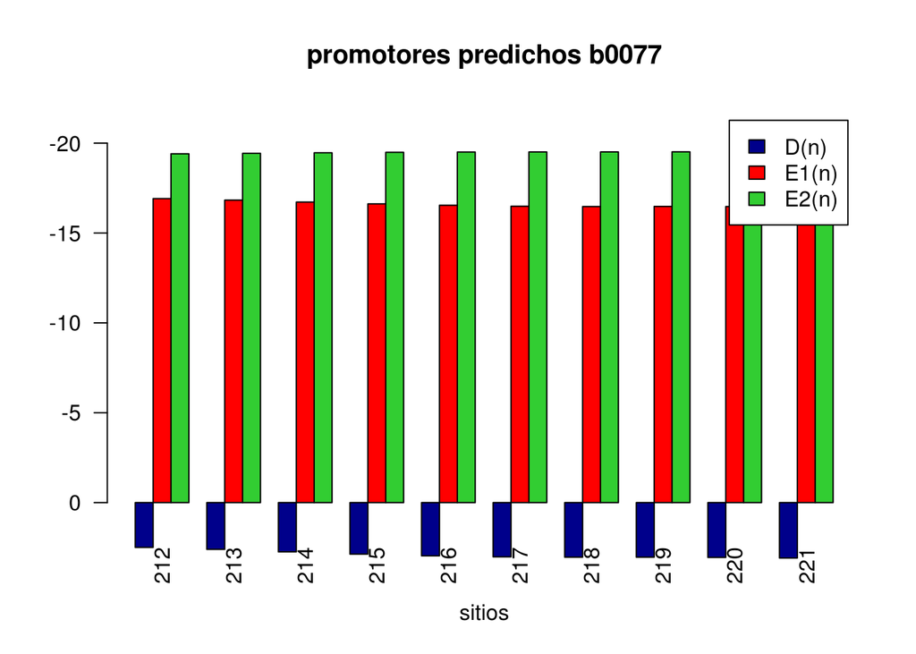

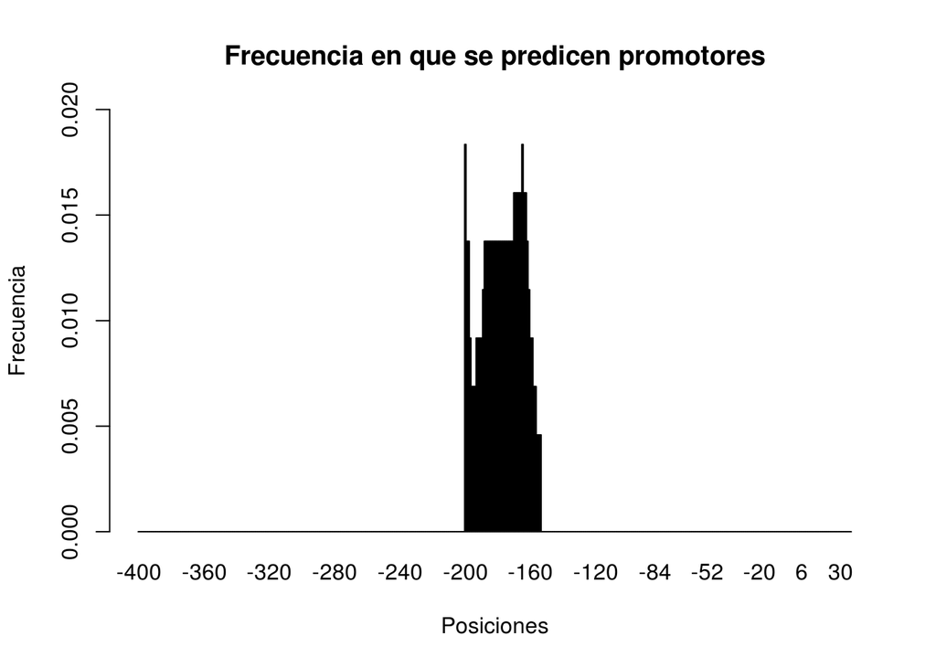

Tomando en cuenta los falsos positivos:

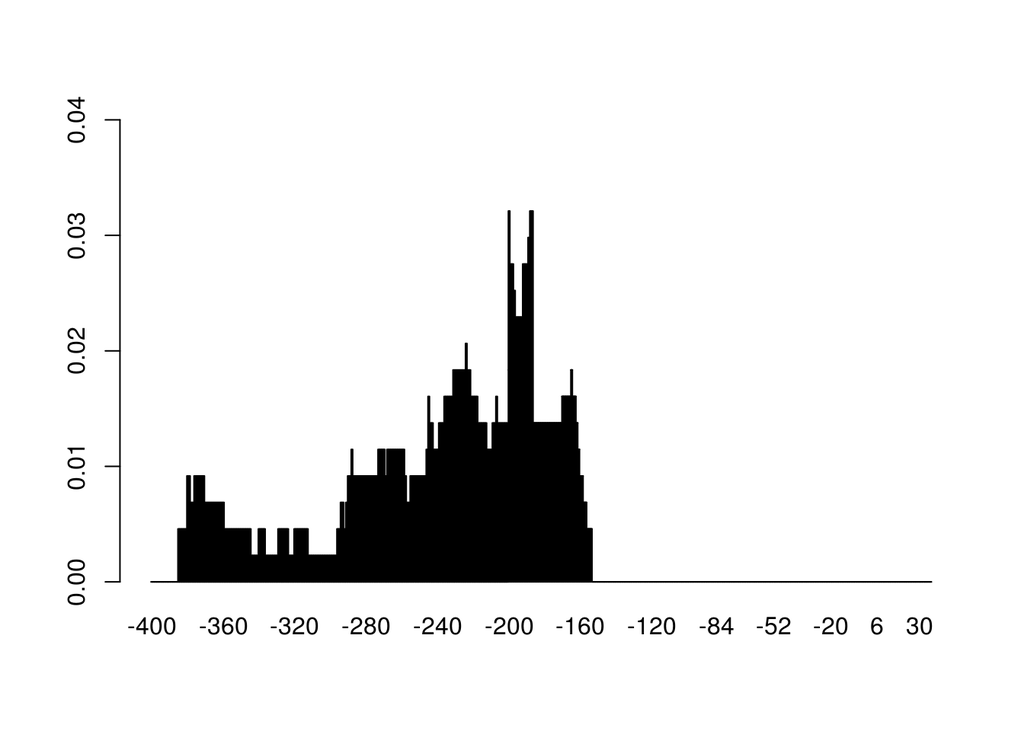

Con la modificación de los valores de cut-off se observa que la frecuencia de predicción de promotores disminuye. El número de sitios se mantiene pero la cantidad de secuencias en las que se pudieron predecir promotores disminuyó. La precisión aumentó muy poco, es ahora de 0.24.